# Part 2(a&b)

Chin Joey

2025-02-22

Part 2(a) 1.Identify columns with missing values 2.Remove rows with missing key values 3.Adjust delays, categorize flight times and extract days of the week 4.Calculate average delays by time of day and day of the week 5.Plot bar charts to show the best times and best days to fly with the lowest delays

Load libraries

```r
library(tidyr)
library(lubridate)
library(dplyr)
```

```r
library(ggplot2)
```

Load data and import it into data frame

```r
airports_df <- read.csv("airports.csv", header = TRUE)
carriers_df <- read.csv("carriers.csv", header = TRUE)
planes_df <- read.csv ("plane-data.csv", header = TRUE)
ontime_df <- data.frame()
for (year in 2004:2008) {
  file_path <- paste0(year, ".csv/", year, ".csv")
  yearly_data <- read.csv(file_path, header = TRUE)
  ontime_df <- rbind(ontime_df, yearly_data)
}
```

Check which col has NA

```r
names(which(colSums(is.na(ontime_df)) > 0))
```

```
##  [1] "DepTime"           "ArrTime"           "ActualElapsedTime"
##  [4] "CRSElapsedTime"    "AirTime"           "ArrDelay"
##  [7] "DepDelay"          "TaxiIn"            "TaxiOut"
## [10] "CarrierDelay"      "WeatherDelay"      "NASDelay"
## [13] "SecurityDelay"     "LateAircraftDelay"
```

Data Cleaning and Adjustment 1.Remove NA values for accurate analysis 2.Consider minor delays (<15 mins) as no delay 3.Create total delay, time category and weekday features 4.Drop invalid time categories

```r
part_a_df <- ontime_df %>%
  filter(!is.na(DepTime) & !is.na(DepDelay) & !is.na(ArrDelay)) %>%
  mutate(
    # Replace delays < 15 min with 0
    DepDelay = ifelse(DepDelay < 15, 0, DepDelay),
    ArrDelay = ifelse(ArrDelay < 15, 0, ArrDelay),

    # Calculate total delay after adjustments
    TotDelay = DepDelay + ArrDelay,
    Hour = floor(DepTime / 100),  # Extract hour from DepTime
    TimeCategory = case_when(
      Hour >= 0 & Hour < 6  ~ "Early Morning",
      Hour >= 6 & Hour < 12 ~ "Morning",
      Hour >= 12 & Hour < 18 ~ "Afternoon",
      Hour >= 18 & Hour < 24 ~ "Night"
    ),

    # Convert date columns to actual date format
    Date = as.Date(with(., paste(DayofMonth, Month, Year, sep="-")), format="%d-%m-%Y"),

    # Extract day of the week
    DayOfWeek = wday(Date, label = TRUE)
  ) %>%

  filter(!is.na(TimeCategory))
```

Analyze Best Flight Times 1.Group data by time category 2.Calculate and sort average delays to find the best times

```r
best_flight_times <- part_a_df %>%
                     group_by(TimeCategory) %>%
                     summarise(AvgDelay = mean(TotDelay)) %>%
                     arrange(AvgDelay)

# Best flight times table
print(best_flight_times)
```

```
## # A tibble: 4 × 2
##   TimeCategory  AvgDelay
##   <chr>            <dbl>
## 1 Morning           10.2
## 2 Afternoon         22.6
## 3 Early Morning     29.3
## 4 Night             43.9
```

Analyze Best Flight Days 1.Group data by weekday 2.Calculate and sort average delays to find the best days

```r
best_flight_days <- part_a_df %>%
                    group_by(DayOfWeek) %>%
                    summarise(AvgDelay = mean(TotDelay)) %>%
                    arrange(AvgDelay)

# Best flight days table
print(best_flight_days)
```

```
## # A tibble: 7 × 2
##   DayOfWeek AvgDelay
##   <ord>        <dbl>
## 1 Sat           18.1
## 2 Tue           20.1
## 3 Wed           22.0
## 4 Sun           22.8
## 5 Mon           23.7
## 6 Thu           25.4
## 7 Fri           26.4
```

Visualize optimal flight times with the lowest delays

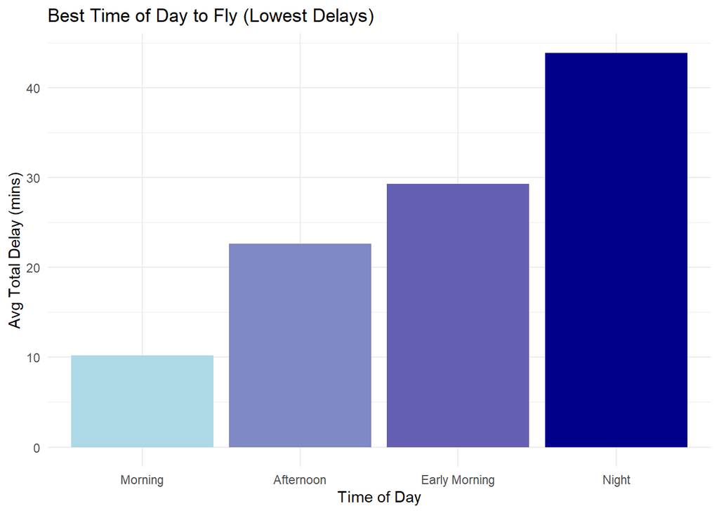

```r
ggplot(best_flight_times, aes(x = reorder(TimeCategory, AvgDelay), y = AvgDelay, fill = AvgDelay)) +
  geom_col(show.legend = FALSE) +
  scale_fill_gradient(low = "lightblue", high = "darkblue") +
  labs(title = "Best Time of Day to Fly (Lowest Delays)", x = "Time of Day", y = "Avg Total Delay (mins)") +
  theme_minimal()
```

Visualize optimal flight days with the lowest delays

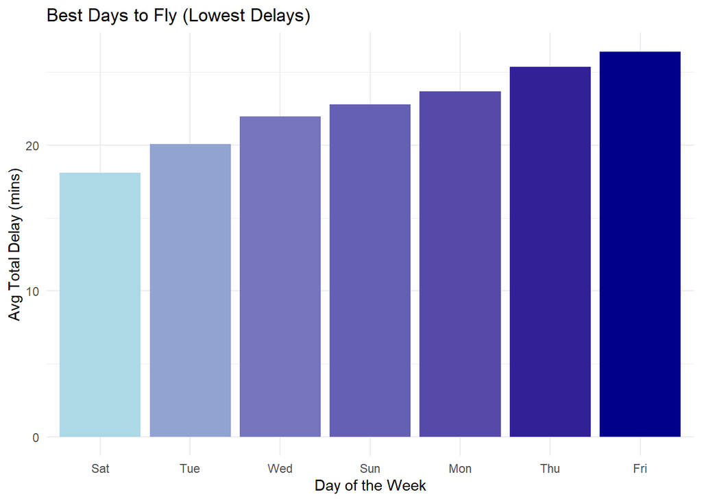

```r
ggplot(best_flight_days, aes(x = reorder(DayOfWeek, AvgDelay), y = AvgDelay, fill = AvgDelay)) +
  geom_col(show.legend = FALSE) +
  scale_fill_gradient(low = "lightblue", high = "darkblue") +
  labs(title = "Best Days to Fly (Lowest Delays)", x = "Day of the Week", y = "Avg Total Delay (mins)") +
  theme_minimal()
```

Part 2 (b) 1.Filter out cancelled and diverted flights to focus on delays 2.Calculate plane age by comparing flight year to manufacturing year 3.Adjust delays by considering minor delays (<15 mins) as zero 4.Aggregate data to compute average delays per plane age 5.Visualize results with a line plot (age vs. average delay) 6.Analyze trend to determine if older planes experience more delays

Load libraries

```r
library(dplyr)
library(tidyr)
library(ggplot2)
```

Load data and import it into data frame

```r
airports_df <- read.csv("airports.csv", header = TRUE)
carriers_df <- read.csv("carriers.csv", header = TRUE)
planes_df <- read.csv ("plane-data.csv", header = TRUE)
ontime_df <- data.frame()
for (year in 2004:2008) {
  file_path <- paste0(year, ".csv/", year, ".csv")
  yearly_data <- read.csv(file_path, header = TRUE)
  ontime_df <- rbind(ontime_df, yearly_data)
}
```

Remove cancelled and diverted flights, select relevant attributes 1.Exclude cancelled and diverted flights (set to NA and drop) 2.Retain only columns needed for analysis (Year, TailNum, delays)

```r
part_b_df <- ontime_df %>%
  mutate(
    Cancelled = ifelse(Cancelled == 1, NA, Cancelled),
    Diverted = ifelse(Diverted == 1, NA, Diverted)
  ) %>%
  drop_na(Cancelled, Diverted) %>%
  select(Year, TailNum, ArrDelay, DepDelay)
```

Merge data and calculate age 1.Merge flight data with plane manufacturing years 2.Calculate plane age and filter NA and unrealistic values

```r
part_b_merged_df <- part_b_df %>%
  left_join(planes_df %>% select(TailNum = tailnum, plane_year = year), by = "TailNum")

part_b_merged_df <- part_b_merged_df %>%
  mutate(
    Year = as.integer(Year),
    plane_year = as.integer(gsub("[^0-9]", "", plane_year)),  # Keeps only digits
    Age = Year - plane_year
  ) %>%
  filter(!is.na(plane_year), Age >= 0 & Age <= 100)
```

Adjust Delays and compute total delay 1.Ignore minor delays (<15 mins) 2.Create a total delay

```r
part_b_merged_df <- part_b_merged_df %>%
  mutate(
    DepDelay = ifelse(DepDelay < 15, 0, DepDelay), # Replace DepDelay and ArrDelay < 15 with 0
    ArrDelay = ifelse(ArrDelay < 15, 0, ArrDelay),
    totdelay = ArrDelay + DepDelay
  )
```

Aggregate: Compute average total delay by aircraft age

```r
part_b_graph_df <- part_b_merged_df %>%
  group_by(Age) %>%
  summarise(avg_totdelay = mean(totdelay, na.rm = TRUE)) %>%
  ungroup()
```

Plot the relationship between plane age and average delays

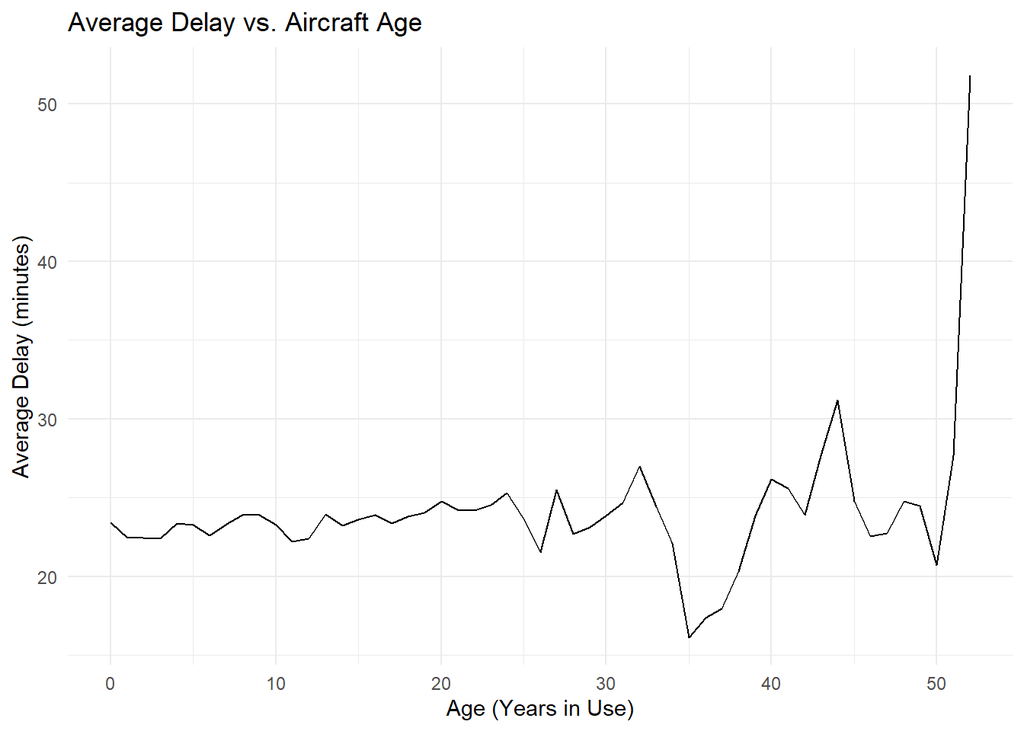

```r
ggplot(part_b_graph_df, aes(x = Age, y = avg_totdelay)) +
  geom_line(color = "black") +
  labs(title = "Average Delay vs. Aircraft Age",
       x = "Age (Years in Use)",
       y = "Average Delay (minutes)") +
  theme_minimal()
```